# 2. Logistic regression

One way to move on from linear regression is to consider settings where the dependent (target) variable is **discrete**. This opens a wide range of possibilities for modelling phenomena beyond the assumptions of continuity or normality.

**Logistic regression** is a powerful method that is well suited for predicting and classifying data by working with **probabilities**. It belongs to a large family of statistical models called **Generalized Linear Models** (GLM). An important special case that involves a **binary** target (taking only the values 0 or 1) is the most typical and popular form of logistic regression.

We will learn the concept of **odds ratio** (OR), which helps to understand and interpret the estimated coefficients of a logistic regression model. We also take a brief look at **cross-validation**, an important principle and technique for assessing the performance of a statistical model with another data set, for example by splitting the data into a **training set** and a **testing set**.

### Data set information

The dataset is a result of high school student performance measured from two Portuguese schools, in relation to their alcohol consumption. More detailed information about the original dataset can be found here https://archive.ics.uci.edu/ml/datasets/Student+Performance.

This dataset uses “school”, “sex”, “age”, “address”, “famsize”, “Pstatus”, “Medu”, “Fedu”, “Mjob”, “Fjob”, “reason”, “nursery”,“internet” as (student) identifiers. The rest are personal attributes describing their life, performance and alcohol consumptions.

The dataset includes 382 records with the 35 variables comprised of the mentioned above. **high_use** is determined based on quantified value of **alc_use**. **alc_use** is calculated based on both weekday (**Dalc**) and weekend (**Walc**) alcohol consumption:

```r
str(alc)
```

```
## 'data.frame':    382 obs. of  35 variables:
##  $ school    : Factor w/ 2 levels "GP","MS": 1 1 1 1 1 1 1 1 1 1 ...
##  $ sex       : Factor w/ 2 levels "F","M": 1 1 1 1 1 2 2 1 2 2 ...
##  $ age       : int  18 17 15 15 16 16 16 17 15 15 ...
##  $ address   : Factor w/ 2 levels "R","U": 2 2 2 2 2 2 2 2 2 2 ...
##  $ famsize   : Factor w/ 2 levels "GT3","LE3": 1 1 2 1 1 2 2 1 2 1 ...
##  $ Pstatus   : Factor w/ 2 levels "A","T": 1 2 2 2 2 2 2 1 1 2 ...
##  $ Medu      : int  4 1 1 4 3 4 2 4 3 3 ...
##  $ Fedu      : int  4 1 1 2 3 3 2 4 2 4 ...
##  $ Mjob      : Factor w/ 5 levels "at_home","health",..: 1 1 1 2 3 4 3 3 4 3 ...
##  $ Fjob      : Factor w/ 5 levels "at_home","health",..: 5 3 3 4 3 3 3 5 3 3 ...
##  $ reason    : Factor w/ 4 levels "course","home",..: 1 1 3 2 2 4 2 2 2 2 ...
##  $ nursery   : Factor w/ 2 levels "no","yes": 2 1 2 2 2 2 2 2 2 2 ...
##  $ internet  : Factor w/ 2 levels "no","yes": 1 2 2 2 1 2 2 1 2 2 ...
##  $ guardian  : Factor w/ 3 levels "father","mother",..: 2 1 2 2 1 2 2 2 2 2 ...
```

[output cut: 21 more lines]

### Hypotheses

Amongst the variables, student final grade (**G3**), **absences**, weekly study time (**studytime**) as well as whether or not student go out with friends (**goout**) are some of the major factors that might influence their alcohol consumption. The consumption is generally known for affecting human cognitive performance and sleep/wake cycles, therefore student **G3**, **absences** and **studytime** are possibly associated. Socializing habit such as going out with friends is culturally associated with alcohol usage, thus **goout** is another factor to be examined.

### Numerical and graphical overview

Here is a brief summary of the dataset:

```
##  school   sex          age        address famsize   Pstatus
##  GP:342   F:198   Min.   :15.00   R: 81   GT3:278   A: 38
##  MS: 40   M:184   1st Qu.:16.00   U:301   LE3:104   T:344
##                   Median :17.00
##                   Mean   :16.59
##                   3rd Qu.:17.00
##                   Max.   :22.00
##       Medu            Fedu             Mjob           Fjob
##  Min.   :0.000   Min.   :0.000   at_home : 53   at_home : 16
##  1st Qu.:2.000   1st Qu.:2.000   health  : 33   health  : 17
##  Median :3.000   Median :3.000   other   :138   other   :211
##  Mean   :2.806   Mean   :2.565   services: 96   services:107
##  3rd Qu.:4.000   3rd Qu.:4.000   teacher : 62   teacher : 31
##  Max.   :4.000   Max.   :4.000
##         reason    nursery   internet    guardian     traveltime
##  course    :140   no : 72   no : 58   father: 91   Min.   :1.000
##  home      :110   yes:310   yes:324   mother:275   1st Qu.:1.000
##  other     : 34                       other : 16   Median :1.000
##  reputation: 98                                    Mean   :1.448
##                                                    3rd Qu.:2.000
##                                                    Max.   :4.000
##    studytime        failures      schoolsup famsup     paid     activities
##  Min.   :1.000   Min.   :0.0000   no :331   no :144   no :205   no :181
##  1st Qu.:1.000   1st Qu.:0.0000   yes: 51   yes:238   yes:177   yes:201
##  Median :2.000   Median :0.0000
##  Mean   :2.037   Mean   :0.2016
##  3rd Qu.:2.000   3rd Qu.:0.0000
##  Max.   :4.000   Max.   :3.0000
##  higher    romantic      famrel         freetime        goout
##  no : 18   no :261   Min.   :1.000   Min.   :1.00   Min.   :1.000
##  yes:364   yes:121   1st Qu.:4.000   1st Qu.:3.00   1st Qu.:2.000
##                      Median :4.000   Median :3.00   Median :3.000
##                      Mean   :3.937   Mean   :3.22   Mean   :3.113
##                      3rd Qu.:5.000   3rd Qu.:4.00   3rd Qu.:4.000
##                      Max.   :5.000   Max.   :5.00   Max.   :5.000
##       Dalc            Walc           health         absences
##  Min.   :1.000   Min.   :1.000   Min.   :1.000   Min.   : 0.0
##  1st Qu.:1.000   1st Qu.:1.000   1st Qu.:3.000   1st Qu.: 1.0
##  Median :1.000   Median :2.000   Median :4.000   Median : 3.0
##  Mean   :1.482   Mean   :2.296   Mean   :3.573   Mean   : 4.5
##  3rd Qu.:2.000   3rd Qu.:3.000   3rd Qu.:5.000   3rd Qu.: 6.0
##  Max.   :5.000   Max.   :5.000   Max.   :5.000   Max.   :45.0
##        G1              G2              G3           alc_use
##  Min.   : 2.00   Min.   : 4.00   Min.   : 0.00   Min.   :1.000
##  1st Qu.:10.00   1st Qu.:10.00   1st Qu.:10.00   1st Qu.:1.000
##  Median :12.00   Median :12.00   Median :12.00   Median :1.500
##  Mean   :11.49   Mean   :11.47   Mean   :11.46   Mean   :1.889
##  3rd Qu.:14.00   3rd Qu.:14.00   3rd Qu.:14.00   3rd Qu.:2.500
##  Max.   :18.00   Max.   :18.00   Max.   :18.00   Max.   :5.000
##   high_use
##  Mode :logical
##  FALSE:268
##  TRUE :114
##
##
##
```

Student final grade (**G3**) can range from 0 to 20, with the maximum value in the dataset being 18. **Absences** purely represent the number of absences at school (from 0 to 93). **goout** is a numerical value, which range from 1 - very low to 5 - very high. **studytime** is also numerical, with `1 - <2 hours`, `2 - 2 to 5 hours`, `3 - 5 to 10 hours`, `or 4 - >10 hours`.

The following tables give initial hint that support the aforementioned hypotheses, where high alcohol consumption is linked to worse school performance and a more social life style.

```
## # A tibble: 2 x 3
##   high_use count mean_grade
##   <lgl>    <int>      <dbl>
## 1 FALSE      268       11.7
## 2 TRUE       114       10.8
```

```
## # A tibble: 2 x 3
##   high_use count mean_absences
##   <lgl>    <int>         <dbl>
## 1 FALSE      268          3.71
## 2 TRUE       114          6.37
```

```
## # A tibble: 2 x 3
##   high_use count mean_study_time
##   <lgl>    <int>           <dbl>
## 1 FALSE      268            2.15
## 2 TRUE       114            1.77
```

```
## # A tibble: 2 x 3
##   high_use count mean_go_out
##   <lgl>    <int>       <dbl>
## 1 FALSE      268        2.85
## 2 TRUE       114        3.72
```

The following box plots depict the data in a more detailed manner. Even with outliers considered, the data still pretty much in line with the initial hypotheses.

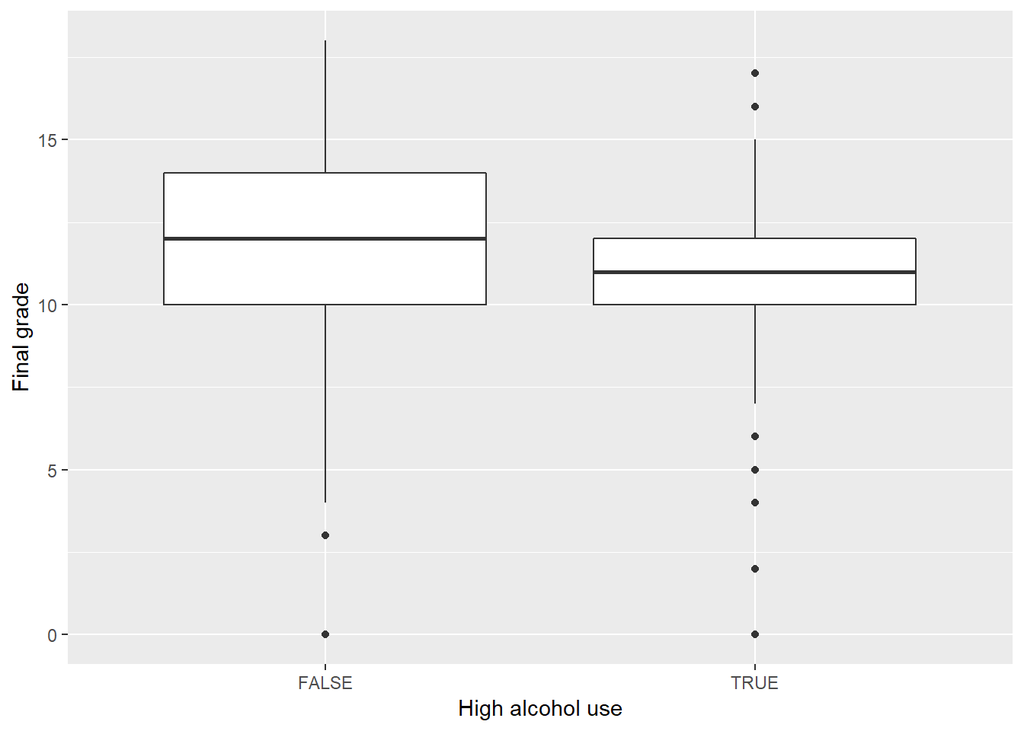

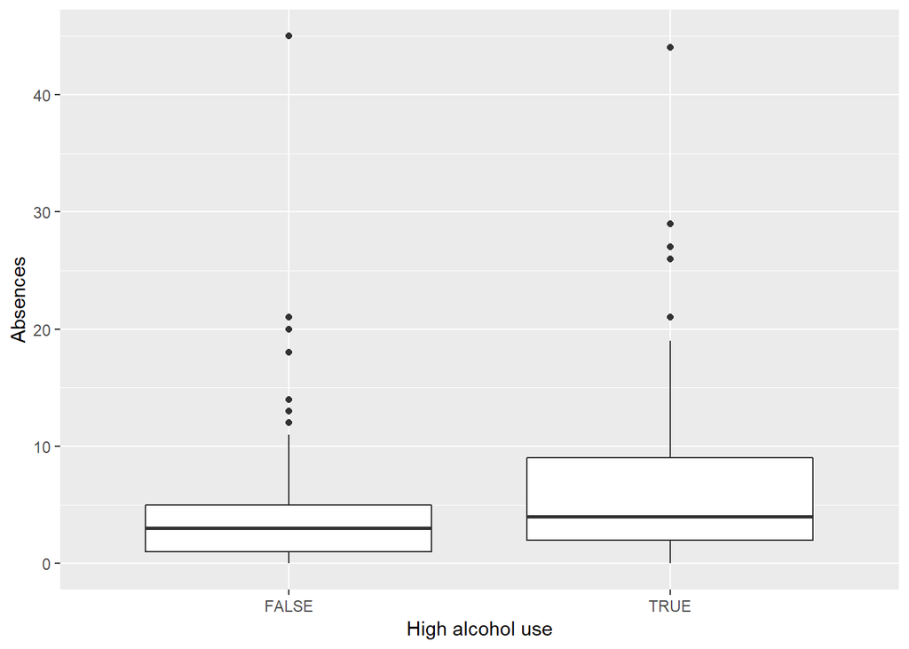

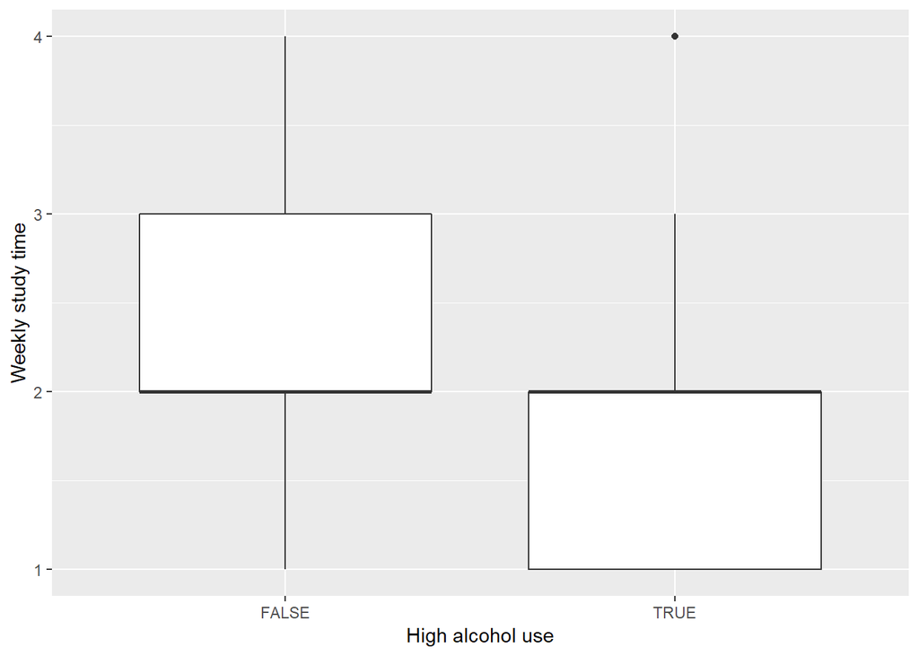

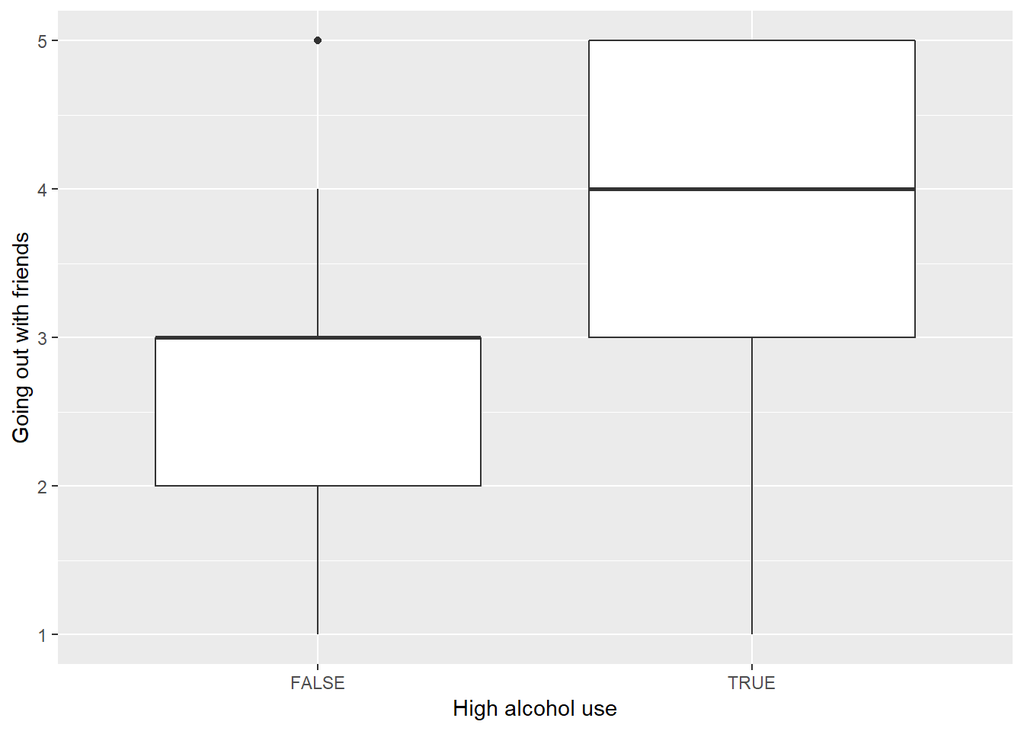

### Logistic regression model and establishing relationships

To make another step towards validating the hypotheses, a logistic regression model is created with **high_use** being the target variable and **G3**, **absences**, **studytime** and **goout** as explanatory variable.

```
##
## Call:
## glm(formula = high_use ~ G3 + absences + studytime + goout, family = "binomial",
##     data = alc)
##
## Deviance Residuals:
##     Min       1Q   Median       3Q      Max
## -1.8717  -0.7686  -0.5171   0.8345   2.4941
##
## Coefficients:
##             Estimate Std. Error z value Pr(>|z|)
## (Intercept) -2.15991    0.69106  -3.125  0.00178 **
## G3          -0.02831    0.03925  -0.721  0.47074
## absences     0.06912    0.02205   3.135  0.00172 **
## studytime   -0.54223    0.16834  -3.221  0.00128 **
## goout        0.71610    0.11855   6.040 1.54e-09 ***
## ---
## Signif. codes:  0 '***' 0.001 '**' 0.01 '*' 0.05 '.' 0.1 ' ' 1
##
## (Dispersion parameter for binomial family taken to be 1)
##
##     Null deviance: 465.68  on 381  degrees of freedom
## Residual deviance: 389.62  on 377  degrees of freedom
## AIC: 399.62
##
## Number of Fisher Scoring iterations: 4
```

With the presented summary of the model above, the absolute **z value** being pretty small and **p value** being rather large for **G3** (final grade). It can be concluded that **G3** is not statistically significant enough to be used as a part of the model. Another simpler model is used instead.

```
##
## Call:
## glm(formula = high_use ~ absences + studytime + goout, family = "binomial",
##     data = alc)
##
## Deviance Residuals:
##     Min       1Q   Median       3Q      Max
## -1.8457  -0.7733  -0.5178   0.8432   2.5036
##
## Coefficients:
##             Estimate Std. Error z value Pr(>|z|)
## (Intercept) -2.48582    0.52982  -4.692 2.71e-06 ***
## absences     0.07011    0.02204   3.181 0.001470 **
## studytime   -0.56048    0.16672  -3.362 0.000774 ***
## goout        0.72735    0.11786   6.171 6.78e-10 ***
## ---
## Signif. codes:  0 '***' 0.001 '**' 0.01 '*' 0.05 '.' 0.1 ' ' 1
##
## (Dispersion parameter for binomial family taken to be 1)
##
##     Null deviance: 465.68  on 381  degrees of freedom
## Residual deviance: 390.14  on 378  degrees of freedom
## AIC: 398.14
##
## Number of Fisher Scoring iterations: 4
```

Odd ratios and confidence intervals is calculated in the table below. Odd ratios of all predictors are well within the range of corresponding confidence intervals. All interval are in general quite narrow, meaning that the model is performing rather well. This confirms previously stated hypotheses ragarding **absences**, **studytime** and **goout** variables.

```
##                     OR      2.5 %    97.5 %
## (Intercept) 0.08325721 0.02864231 0.2297441
## absences    1.07262851 1.02840235 1.1225709
## studytime   0.57093348 0.40733791 0.7846264
## goout       2.06958310 1.65203749 2.6250666
```

### Predictive power

The model managed to predict correctly the majority of cases when the high use is false. It, however, doesn’t perform as well when trying to predict cases where high use is actually true.

```
##         prediction
## high_use FALSE TRUE
##    FALSE   246   22
##    TRUE     66   48
```

The following graph visualizes the actual values and the predictions.

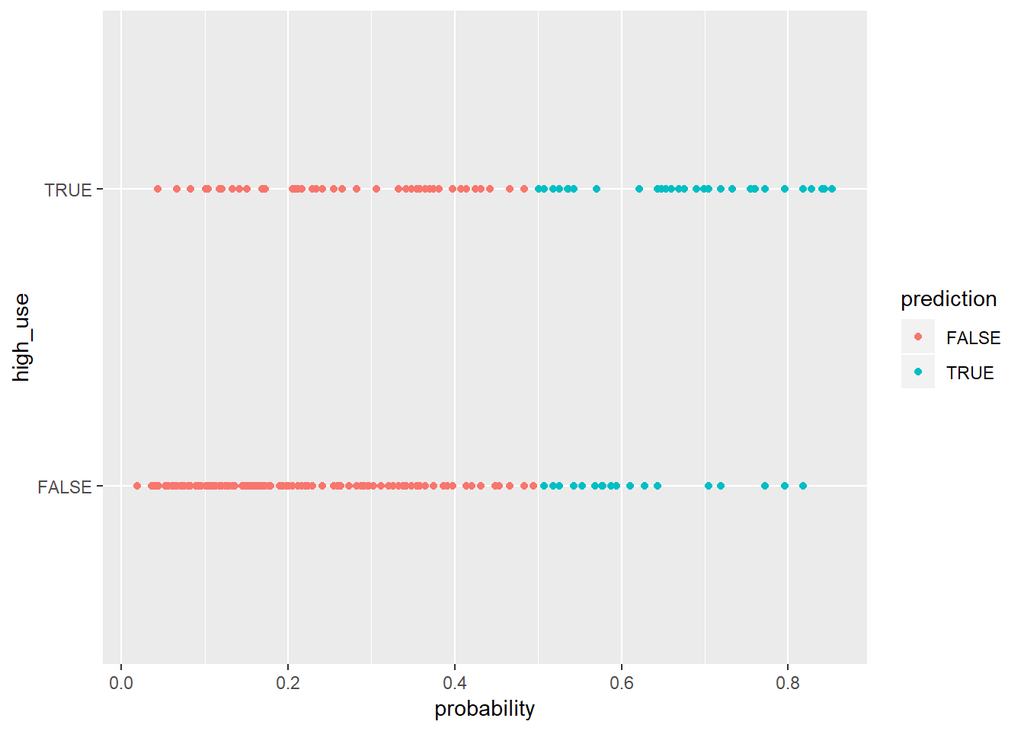

The proportion of inaccurately classified individuals is calculated using the loss function defined below:

```r
# loss function definition
loss_func <- function(class, prob) {
  n_wrong <- abs(class - prob) > 0.5
  mean(n_wrong)
}

# compute the proportion of wrong predictions in the (training) data
loss_func(class = alc$high_use, prob = alc$probability)
```

```
## [1] 0.2303665
```